# Lab 2 KEY

Prof. Amanda D. Perez, PhD

# Libraries

You will need to load the following libraries this week

```r
library(ggplot2)
library(viridis)
library(psych)
library(tidyverse)
library(skimr)
library(scales)
library(forcats)
```

# The Data

This week you will be using data with information test performance. Let’s load it in and take a peek at it.

```r
mydata <- read.csv("~/Dropbox/PSYCH101SU22/R-Labs/Data/SampleDataSet.csv")
head(mydata)
```

```
##   ID Gender    Treatment Test1 Test2
## 1  1   Male      Control    98    32
## 2  2 Female Experimental    87    33
## 3  3 Female      Control    89    54
## 4  4 Female      Control    88    44
## 5  5   Male Experimental    76    64
## 6  6   Male      Control    68    54
```

The `psych` library has a `describe()` function that gives a lot of helpful information.

```r
describe(mydata)
```

```
##            vars  n  mean    sd median trimmed   mad min max range  skew
## ID            1 25 13.00  7.36     13   13.00  8.90   1  25    24  0.00
## Gender*       2 25  1.44  0.51      1    1.43  0.00   1   2     1  0.23
## Treatment*    3 25  1.32  0.48      1    1.29  0.00   1   2     1  0.73
## Test1         4 25 83.52  8.63     86   83.76 10.38  65  98    33 -0.24
## Test2         5 25 64.24 21.64     64   64.00 29.65  32  99    67  0.04
##            kurtosis   se
## ID            -1.34 1.47
## Gender*       -2.02 0.10
## Treatment*    -1.53 0.10
## Test1         -0.79 1.73
## Test2         -1.38 4.33
```

# The Mean

## Exercise 1: Find the mean of Test1

```r
mean(mydata$Test1, na.rm = TRUE)
```

```
## [1] 83.52
```

## Exercise 2: Find the mean of Test2

```r
mean(mydata$Test2, na.rm = TRUE)
```

```
## [1] 64.24
```

## Exercise 3: Which test did people perform better on?

RESPONSE: First Test

# Variance

## Exercise 4: Find the variance of Test1

```r
var(mydata$Test1)
```

```
## [1] 74.42667
```

## Exercise 5: Find the standard deviation of Test1

```r
sd(mydata$Test1)
```

```
## [1] 8.627089
```

## Exercise 6: Interpret how this standard deviation relates to the Test1 data and its mean.

Response: The mean Test1 performance is 83.52. The standard deviation is is 8.63. A small standard deviation means that the values in a dataset are close to the mean (or average) of the dataset, and a large standard deviation means that the values in the dataset are farther away from the mean. The standard deviation is in original units. This means, it is in the unit of test points. One standard deviation is roughly 9 points, which is almost a whole letter grade! This is pretty big variability. In situations where you just observe and record data, a large standard deviation isn’t necessarily a bad thing; it just reflects a large amount of variation in the group that is being studied.

## Exercise 7: Find the variance of Test2

```r
var(mydata$Test2)
```

```
## [1] 468.3567
```

## Exercise 8: Find the standard deviation of Test2

```r
sd(mydata$Test2)
```

```
## [1] 21.64155
```

## Exercise 9: Interpret how this standard deviation relates to the Test2 data and its mean.

Response: The mean Test2 performance is 64.24. The standard deviation is is 21.64155. One standard deviation is roughly 22 points, which 2 letter grades! This is pretty big variability.

## Exercise 10: Fill in the blanks below. The goal is to create three object for Test1.

In the first blank, compute the mean of Test1. The second and third blank should be identical and you should compute the standard deviation of Test1.

```r
mean_test1 <- mean(mydata$Test1)
sd_above1 <- mean_test1 + sd(mydata$Test1)
sd_below1 <- mean_test1 - sd(mydata$Test1)
```

If you were able to correctly assign the values above, the code below will run without error.

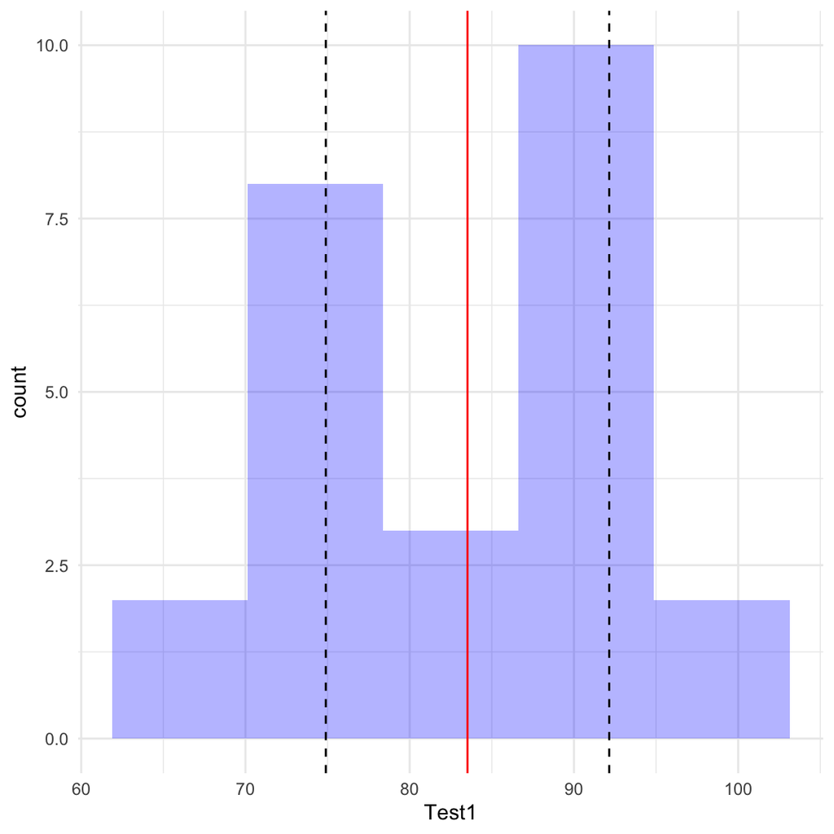

```r
ggplot(mydata, aes(Test1)) +
  geom_histogram(bins = 5, alpha = 0.3,
                 fill = "blue") +
  theme_minimal() +
  geom_vline(xintercept = mean_test1, color = "red") +
  geom_vline(xintercept = c(sd_below1, sd_above1),
             color = "black", linetype = "dashed")
```

## Exercise 11: Fill in the blanks below. The goal is to create three object for Test2.

In the first blank, compute the mean of Test2. The second and third blank should be identical and you should compute the standard deviation of Test2.

```r
mean_test2 <- mean(mydata$Test2)
sd_above2 <- mean(mydata$Test2) + sd(mydata$Test2)
sd_below2 <- mean(mydata$Test2) - sd(mydata$Test2)
```

If you were able to correctly assign the values above, the code below will run without error.

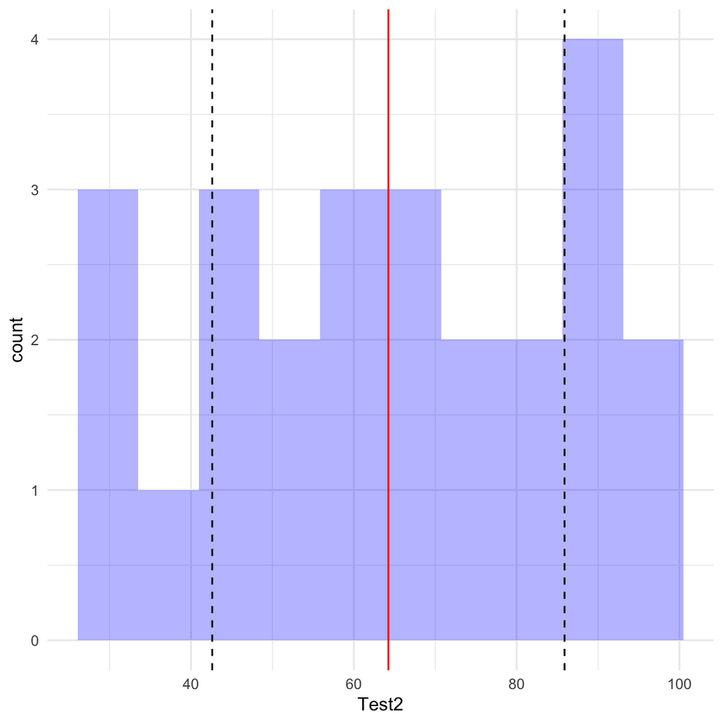

```r
ggplot(mydata, aes(Test2)) +
  geom_histogram(bins = 10, alpha = 0.3,
                 fill = "blue") +
  theme_minimal() +
  geom_vline(xintercept = mean_test2, color = "red") +
  geom_vline(xintercept = c(sd_below2, sd_above2),
             color = "black", linetype= "dashed")
```

## Exercise 12: Look at both histograms and interpret what you see.

Answer: As we calculated previously, Test2 has much higher variability around the mean compared to Test1.

# Hotel bookings + Data Wrangling

```r
# From TidyTuesday: https://github.com/rfordatascience/tidytuesday/blob/master/data/2020/2020-02-11/readme.md
hotels <- read_csv("https://raw.githubusercontent.com/rfordatascience/tidytuesday/master/data/2020/2020-02-11/hotels.csv") %>%
  sample_n(1000)
```

## Exercise 13.

Warm up! Take a look at an overview of the data, `hotels`, with the `glimpse()` function.

```r
glimpse(hotels)
```

```
## Rows: 1,000
## Columns: 32
## $ hotel                          <chr> "City Hotel", "City Hotel", "Resort Hot…
## $ is_canceled                    <dbl> 0, 0, 0, 1, 0, 1, 1, 0, 0, 1, 0, 0, 0, …
## $ lead_time                      <dbl> 67, 181, 203, 14, 180, 130, 265, 14, 17…
## $ arrival_date_year              <dbl> 2017, 2016, 2017, 2015, 2017, 2016, 201…
## $ arrival_date_month             <chr> "May", "July", "August", "October", "Au…
## $ arrival_date_week_number       <dbl> 19, 31, 33, 42, 32, 16, 28, 6, 37, 43, …
## $ arrival_date_day_of_month      <dbl> 13, 26, 19, 15, 7, 13, 9, 9, 8, 16, 17,…
## $ stays_in_weekend_nights        <dbl> 2, 0, 2, 0, 1, 0, 0, 0, 0, 2, 2, 2, 0, …
## $ stays_in_week_nights           <dbl> 2, 4, 5, 1, 2, 4, 2, 3, 3, 3, 2, 1, 3, …
## $ adults                         <dbl> 2, 2, 3, 1, 2, 2, 2, 2, 2, 2, 1, 2, 2, …
## $ children                       <dbl> 0, 0, 0, 0, 0, 0, 0, 2, 0, 0, 1, 0, 0, …
## $ babies                         <dbl> 0, 0, 0, 0, 0, 0, 0, 0, 0, 0, 0, 0, 0, …
## $ meal                           <chr> "BB", "BB", "HB", "BB", "BB", "BB", "BB…
```

[output cut: 19 more lines]

## Exercise 14.

Are people traveling on a whim? Let’s see…

Fill in the blanks for filtering for hotel bookings where the guest is **not** from the US (`country` code `"USA"`) and the `lead_time` is **less than** 1 day.

```r
hotels %>%
  filter(
    country != "USA",
    lead_time < 1
  )
```

```
## # A tibble: 43 × 32
##    hotel        is_canceled lead_time arrival_date_year arrival_date_month
##    <chr>              <dbl>     <dbl>             <dbl> <chr>
##  1 Resort Hotel           0         0              2016 January
##  2 Resort Hotel           0         0              2016 April
##  3 Resort Hotel           0         0              2017 February
##  4 City Hotel             0         0              2016 November
##  5 City Hotel             0         0              2016 December
##  6 Resort Hotel           0         0              2017 February
##  7 Resort Hotel           0         0              2015 December
##  8 Resort Hotel           0         0              2016 April
##  9 City Hotel             0         0              2015 August
## 10 City Hotel             0         0              2015 October
## # … with 33 more rows, and 27 more variables: arrival_date_week_number <dbl>,
## #   arrival_date_day_of_month <dbl>, stays_in_weekend_nights <dbl>,
## #   stays_in_week_nights <dbl>, adults <dbl>, children <dbl>, babies <dbl>,
## #   meal <chr>, country <chr>, market_segment <chr>,
## #   distribution_channel <chr>, is_repeated_guest <dbl>,
## #   previous_cancellations <dbl>, previous_bookings_not_canceled <dbl>,
## #   reserved_room_type <chr>, assigned_room_type <chr>, …
```

## Exercise 15.

How many bookings involve at least 1 child **or** baby?

In the following chunk, replace

- `[AT LEAST]` with the logical operator for “at least” (in two places)
- `[OR]` with the logical operator for “or”

```r
hotels %>%
  filter(
    children >= 1 | babies >= 1
  )
```

```
## # A tibble: 66 × 32
##    hotel        is_canceled lead_time arrival_date_year arrival_date_month
##    <chr>              <dbl>     <dbl>             <dbl> <chr>
##  1 City Hotel             0        14              2017 February
##  2 City Hotel             0       138              2017 June
##  3 Resort Hotel           0       177              2016 June
##  4 City Hotel             1        50              2017 July
##  5 Resort Hotel           0        96              2017 April
##  6 Resort Hotel           0         1              2016 May
##  7 City Hotel             0        55              2017 July
##  8 City Hotel             1       114              2016 May
##  9 City Hotel             0        14              2016 September
## 10 City Hotel             0       116              2016 October
## # … with 56 more rows, and 27 more variables: arrival_date_week_number <dbl>,
## #   arrival_date_day_of_month <dbl>, stays_in_weekend_nights <dbl>,
## #   stays_in_week_nights <dbl>, adults <dbl>, children <dbl>, babies <dbl>,
## #   meal <chr>, country <chr>, market_segment <chr>,
## #   distribution_channel <chr>, is_repeated_guest <dbl>,
## #   previous_cancellations <dbl>, previous_bookings_not_canceled <dbl>,
## #   reserved_room_type <chr>, assigned_room_type <chr>, …
```

## Exercise 16.

Do you think it’s more likely to find bookings with children or babies in city hotels or resort hotels? Test your intuition. Using `filter()` determine the number of bookings in resort hotels (variable `hotel` value “Resort Hotel”) that have more than 1 child (variable `children`) **or** baby (variable `babies`) in the room? Then, do the same for city hotels (variable `hotel` value “City Hotel”), and compare the numbers of rows in the resulting filtered data frames.

```r
hotels %>%
  filter(hotel == "Resort Hotel") %>%
  filter(children > 1 | babies > 1) %>%
  count()
```

```
## # A tibble: 1 × 1
##       n
##   <int>
## 1    12
```

```r
hotels %>%
  filter(hotel == "City Hotel") %>%
  filter(children > 1 | babies > 1) %>%
  count()
```

```
## # A tibble: 1 × 1
##       n
##   <int>
## 1    14
```

## Exercise 17.

Create a frequency table (using `count`) of the number of `adults` in a booking. Display the results in descending order so the most common observation is on top. What is the most common number of adults in bookings in this dataset? Are there any surprising results?

```r
hotels %>%
  count(adults, sort = TRUE)
```

```
## # A tibble: 5 × 2
##   adults     n
##    <dbl> <int>
## 1      2   750
## 2      1   191
## 3      3    55
## 4      0     2
## 5      4     2
```

## Exercise 18.

Repeat Exercise 17, once for canceled bookings (`is_canceled` coded as 1) and once for not canceled bookings (`is_canceled` coded as 0). To achieve this, use `filter`.

What does this reveal about the surprising results you spotted in the previous exercise?

```r
hotels %>%
  filter(is_canceled == 1) %>%
  count(adults, sort = TRUE)
```

```
## # A tibble: 4 × 2
##   adults     n
##    <dbl> <int>
## 1      2   290
## 2      1    59
## 3      3    15
## 4      0     1
```

```r
hotels %>%
  filter(is_canceled == 0) %>%
  count(adults, sort = TRUE)
```

```
## # A tibble: 5 × 2
##   adults     n
##    <dbl> <int>
## 1      2   460
## 2      1   132
## 3      3    40
## 4      4     2
## 5      0     1
```

## Exercise 19.

Calculate minimum, mean, median, and maximum average daily rate (`adr`) grouped by `hotel` type so that you can get these statistics separately for resort and city hotels. Which type of hotel is higher, on average?

```r
hotels %>%
  group_by(hotel) %>%
  summarize(`Mean ADR` = mean(adr, na.rm = TRUE),
            `Median ADR` = median(adr, na.rm = TRUE),
            `Min ADR` = min(adr, na.rm = TRUE),
            `Max ADR` = max(adr, na.rm = TRUE))
```

```
## # A tibble: 2 × 5
##   hotel        `Mean ADR` `Median ADR` `Min ADR` `Max ADR`
##   <chr>             <dbl>        <dbl>     <dbl>     <dbl>
## 1 City Hotel        104.         100           0      297.
## 2 Resort Hotel       92.8         74.5         0      340
```